# Array Programming with Python

## Recognizing Musical Chords

## Musical Scale

[figure not shown]

#### Musical Notes

Given the musical notes are geometric progression

$$ f_{13} = 2 f_{1} $$

where

$$ f_{13} = \delta f_{12} \\ f_{13} = \delta (\delta f_{11}) \\ f_{13} = \delta^{2} f_{11} \\ f_{13} = \delta^{12} f_{1} $$

equaling the first equation with the second we get:

$$ 2 f_{1} = \delta^{12} f_{1} \\ 2 = \delta^{12} \\ \delta = \sqrt[12]{2} $$

Thus the common ration is $\sqrt[12]{2}$.

#### The Standard Frequency

In 1953 the International Standards Organization (ISO) set $440~Hz$ as the standard frequency.

[figure not shown]

#### Calculating Notes

Based on that we get obtain frequencies for other notes and octaves:

$$ f = (440) ~ 2^{m -5} \delta^{n + 2} \\ f = \frac{(440) ~ 2^m}{2^5} (\sqrt[12]{2})^{n + 2} \\ f = \frac{(440) ~ 2^m}{2^5} 2^\frac{n + 2}{12} \\ f = \frac{440}{32} ~ 2^{m + \frac{n+2}{12}} \\ f = (13,75) ~ 2^{m + \frac{n+2}{12}} $$

#### Calculating Notes

```python
notes = np.array(['C', 'C#', 'D', 'D#', 'E', 'F', 'F#', 'G', 'G#', 'A', 'A#', 'B'])
notes_indexes = np.arange(1, len(notes) + 1)
octaves = np.arange(1, 5)
def get_frequency(octave_num, note_num):
    return 13.75 * 2 ** (octave_num + ((note_num + 2) / 12))
notes_matrix = [
    [get_frequency(octave_num, note_num) for octave_num in octaves]
    for note_num in notes_indexes
]
notes_df = pd.DataFrame(notes_matrix, index=notes, columns=octaves)
notes_df
```

|  | 1 | 2 | 3 | 4 |
| --- | --- | --- | --- | --- |
| C | 32.703196 | 65.406391 | 130.812783 | 261.625565 |
| C# | 34.647829 | 69.295658 | 138.591315 | 277.182631 |
| D | 36.708096 | 73.416192 | 146.832384 | 293.664768 |
| D# | 38.890873 | 77.781746 | 155.563492 | 311.126984 |
| E | 41.203445 | 82.406889 | 164.813778 | 329.627557 |
| F | 43.653529 | 87.307058 | 174.614116 | 349.228231 |
| F# | 46.249303 | 92.498606 | 184.997211 | 369.994423 |
| G | 48.999429 | 97.998859 | 195.997718 | 391.995436 |
| G# | 51.913087 | 103.826174 | 207.652349 | 415.304698 |
| A | 55.000000 | 110.000000 | 220.000000 | 440.000000 |
| A# | 58.270470 | 116.540940 | 233.081881 | 466.163762 |
| B | 61.735413 | 123.470825 | 246.941651 | 493.883301 |

#### Musical Chords

Triad chords are formed by three notes each.

```python
def get_triad(main_note, triad_interval):
    return [notes[(main_note + interval - 1) % 12] for interval in triad_interval]

major_intervals = [0, 4, 7]  # I, III, V
minor_intervals = [0, 3, 7]  # I, III min, V
```

#### Triad Chords

```python
major_chords = pd.DataFrame({
    notes[main_note - 1] + '+': get_triad(main_note, major_intervals) for main_note in notes_indexes
})
minor_chords = pd.DataFrame({
    notes[main_note - 1] + '-': get_triad(main_note, minor_intervals) for main_note in notes_indexes
})
chords = pd.concat([major_chords, minor_chords], axis=1).transpose()
chords.iloc[:3], '...', chords.iloc[-3:]
```

```
(      0   1   2
 C+    C   E   G
 C#+  C#   F  G#
 D+    D  F#   A,
 '...',
       0   1   2
 A-    A   C   E
 A#-  A#  C#   F
 B-    B   D  F#)
```

#### Audio Input

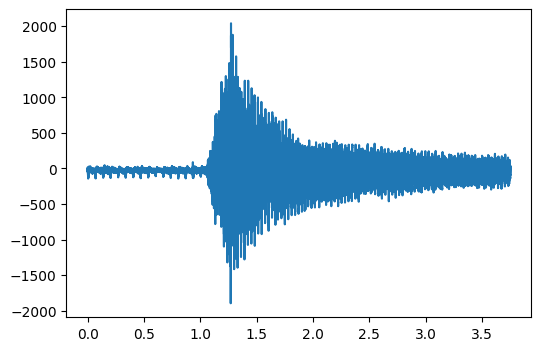

```python
from scipy.io import wavfile
from os.path import dirname, join as pjoin

sampling_frequency, stereo_data = wavfile.read('audio/cC-2.wav')
audio_data = stereo_data[:, 0]  # Taking only one channel
sampling_period = 1 / sampling_frequency
sample_length = audio_data.shape[0]
duration = sample_length * sampling_period
time = np.arange(0, duration, sampling_period)
plt.plot(time, audio_data);
```

#### Fast Fourier Transform (FFT)

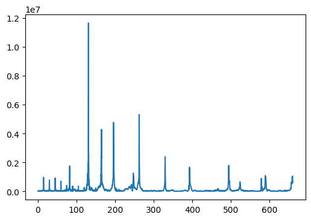

```python
from scipy.fft import fft, fftfreq, fftshift

spectrum = fftshift(fft(audio_data))
freq = fftshift(fftfreq(sample_length, sampling_period))
all_sp = pd.DataFrame(np.abs(spectrum), index=freq)
guitar_max_freq = 660.0  # Hz
guitar_spectrum = all_sp[(all_sp.index > 0) & (all_sp.index < guitar_max_freq)]
plt.plot(guitar_spectrum);
```

#### Getting Top 6 Frequencies

```python
top6 = pd.Series(guitar_spectrum.sort_values(by=0, ascending=False).index[:6])
top6.tolist()
```

```
[131.2, 130.93333333333334, 262.4, 196.0, 165.06666666666666, 164.8]
```

#### Matching Frequencies to Notes

```python
def find_note(f):
    a = notes_df[np.isclose(notes_df, f, atol=1)].index
    if len(a) > 0:
        return a[0]
    else:
        return None

detected_notes = set(top6.map(find_note).dropna())
detected_notes
```

```
{'C', 'E', 'G'}
```

#### Matching Notes to Chords

```python
chords[chords.isin(detected_notes)].dropna().index.item()
```

```
'C+'
```

# References

- NumPy: https://numpy.org
- pandas: https://pandas.pydata.org
- Matplotlib: https://matplotlib.org
- SciPy ecosystem home page: https://scipy.org

## More Widely Used Libraries

- Plotly: Graphing library makes interactive, publication-quality graphs.
  - https://plotly.com/python/
- seaborn: Statistical data visualization
  - https://seaborn.pydata.org
- Dask: Flexible library for parallel computing in Python.
  - https://www.dask.org
- TensorFlow: Create machine learning models for desktop, mobile, web, and cloud.
  - https://www.tensorflow.org
  - https://js.tensorflow.org
- PyTorch: Open source machine learning framework
  - https://pytorch.org